# Reproducible Research Course Project 1

acaf

3/23/2022

# Assignment Instruction

This assignment will be described in multiple parts. You will need to write a report that answers the questions detailed below. Ultimately, you will need to complete the entire assignment in a single R markdown document that can be processed by knitr and be transformed into an HTML file.

# About the Data

The data for this assignment can be downloaded from the course web site:

Dataset: Activity monitoring data [52K] (https://d396qusza40orc.cloudfront.net/repdata%2Fdata%2Factivity.zip)

The variables included in this dataset are:

steps: Number of steps taking in a 5-minute interval (missing values are coded as NA)

date: The date on which the measurement was taken in YYYY-MM-DD format

interval: Identifier for the 5-minute interval in which measurement was taken

The dataset is stored in a comma-separated-value (CSV) file and there are a total of 17,568 observations in this dataset.

## Task 1.1: Loading the data

First, I’ll be needing to download, unzip and save the dataset in my working directory.

```r
filename <- "Activity_monitoring_data.zip"

if (!file.exists(filename)) {
  download_url <- "https://d396qusza40orc.cloudfront.net/repdata%2Fdata%2Factivity.zip"
  download.file(download_url, destfile = filename)
  unzip (zipfile = filename)
}

if (!exists("activity.csv")) {
    unzip("Activity_monitoring_data.zip")
}

datafile <- read.csv("activity.csv", header = TRUE)
```

## Task 1.2: Preprocessing the data

After the dataset has been downloaded, I shall perform simple exploratory to be familiar with the data.

```r
str(datafile)
```

```
## 'data.frame':    17568 obs. of  3 variables:
##  $ steps   : int  NA NA NA NA NA NA NA NA NA NA ...
##  $ date    : chr  "2012-10-01" "2012-10-01" "2012-10-01" "2012-10-01" ...
##  $ interval: int  0 5 10 15 20 25 30 35 40 45 ...
```

```r
head(datafile)
```

```
##   steps       date interval
## 1    NA 2012-10-01        0
## 2    NA 2012-10-01        5
## 3    NA 2012-10-01       10
## 4    NA 2012-10-01       15
## 5    NA 2012-10-01       20
## 6    NA 2012-10-01       25
```

```r
tail(datafile)
```

```
##       steps       date interval
## 17563    NA 2012-11-30     2330
## 17564    NA 2012-11-30     2335
## 17565    NA 2012-11-30     2340
## 17566    NA 2012-11-30     2345
## 17567    NA 2012-11-30     2350
## 17568    NA 2012-11-30     2355
```

```r
datafile_2 <- na.omit(datafile)
```

# Before diving in my analysis on the data, I will load first the necessary packages I’ll be needing for this project.

```r
library(tidyverse)
library(knitr)
library(Hmisc)
```

## Task 2: What is mean total number of steps taken per day?

To find this, we need to calculate the total steps per day and display it in bar chart.

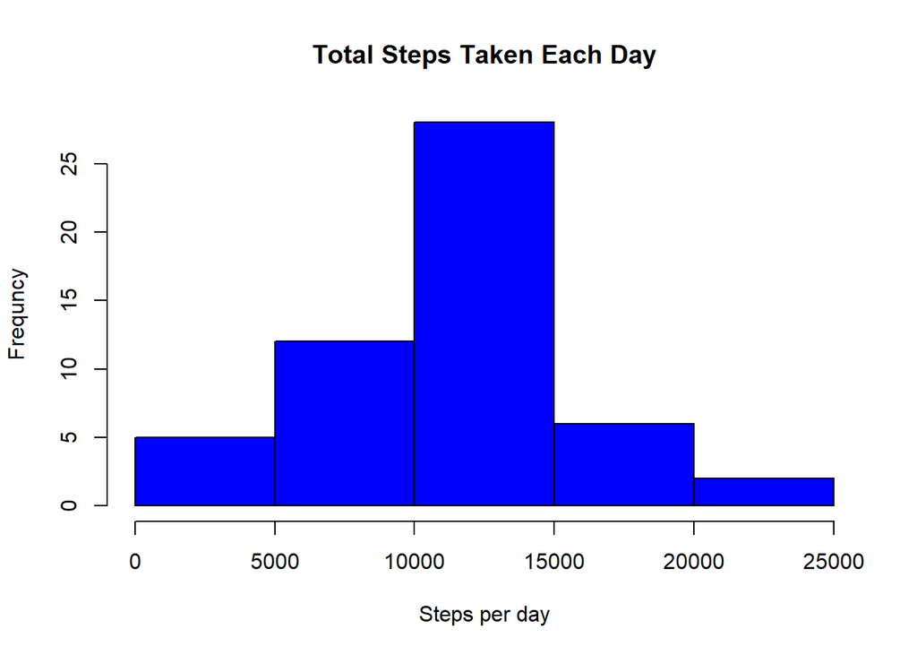

```r
data_steps <- aggregate(steps ~ date, datafile_2, FUN = "sum")
hist(data_steps$steps, col = "blue", xlab = "Steps per day", ylab = "Frequncy", main = "Total Steps Taken Each Day")
```

Then we calculate and report the mean and median of the total number of steps taken per day:

```r
# Calculate the mean
steps_mean <- mean(data_steps[,2])
steps_mean
```

```
## [1] 10766.19
```

```r
#Calculate the median
steps_median <- median(data_steps[,2])
steps_median
```

```
## [1] 10765
```

## Task 3: What is the average daily activity pattern?

1. Make a time series plot (i.e. type = “l”) of the 5-minute interval (x-axis) and the average number of steps taken, averaged across all days (y-axis).

```r
data_avg <- aggregate(datafile_2$steps, by = list(Interval = datafile_2$interval), FUN = "mean")
```

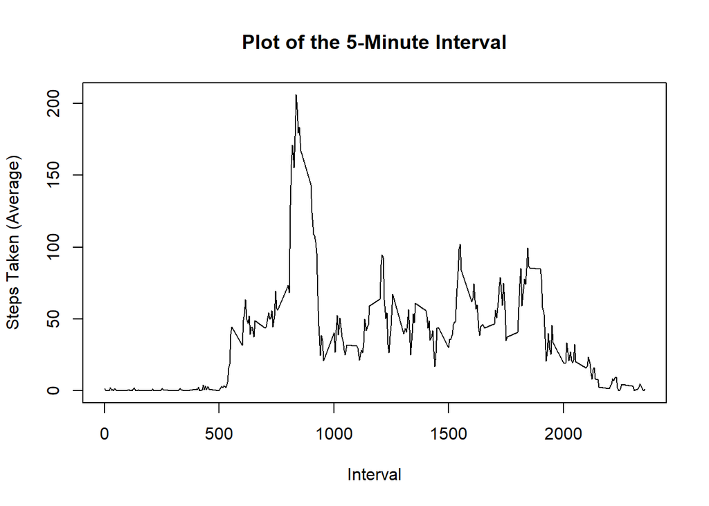

```r
plot(data_avg$Interval, data_avg$x, type = "l", main = "Plot of the 5-Minute Interval", ylab = "Steps Taken (Average)", xlab = "Interval")
```

2. Which 5-minute interval, on average across all the days in the dataset, contains the maximum number of steps?

```r
fivemin <- which.max(data_avg$x)
fivemin_max <- data_avg[fivemin,1]
fivemin_max
```

```
## [1] 835
```

## Task 4: Imputing missing values

Note that there are a number of days/intervals where there are missing values (coded as NA). The presence of missing days may introduce bias into some calculations or summaries of the data.

1. Calculate the total number of NA.

```r
count_na <- length(which(is.na(datafile$steps)))
count_na
```

```
## [1] 2304
```

2. Devise a strategy for filling in all of the missing values in the dataset.

```r
fill_value <- datafile
fill_value$steps <- impute(datafile$steps, fun=mean)
```

The strategy does not need to be sophisticated.

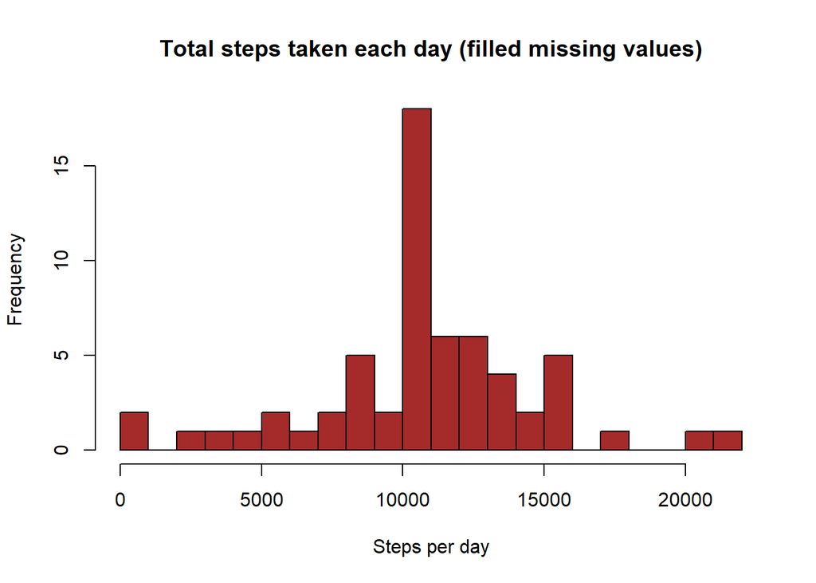

```r
removed_na <- aggregate(fill_value$steps, by = list(Steps.Date = fill_value$date), FUN = "sum")
hist(removed_na$x, col = "brown", breaks = 20, main = "Total steps taken each day (filled missing values)", xlab = "Steps per day")
```

Calculate and report the mean and median total number of steps taken per day.

```r
removed_na_mean <- mean(removed_na[,2])
removed_na_mean
```

```
## [1] 10766.19
```

```r
removed_na_median <- median(removed_na[,2])
removed_na_median
```

```
## [1] 10766.19
```

For this part the weekdays() function may be of some help here. Use the dataset with the filled-in missing values for this part.

```r
fill_value$date <- as.Date(fill_value$date)
fill_value$weekday <- weekdays(fill_value$date)
fill_value$day_type <- ifelse(fill_value$weekday=="суббота" | fill_value$weekday=="воскресенье","Weekend","Weekday")
fill_value$day_type <- factor(fill_value$day_type)
```

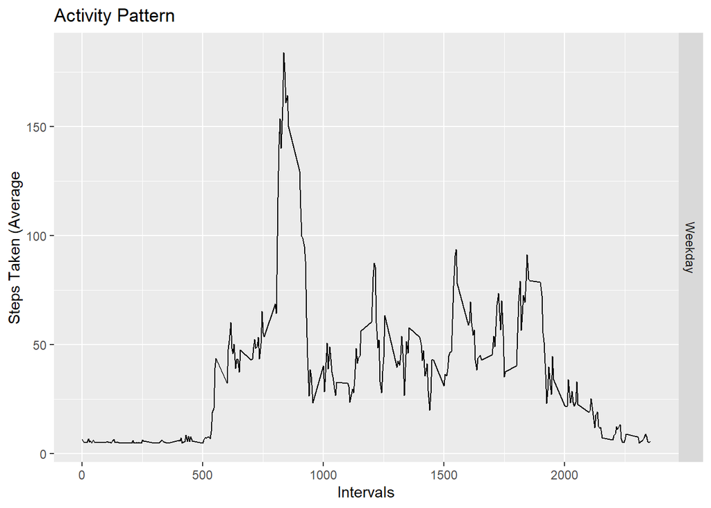

```r
final_data <- aggregate(steps ~ interval + day_type, data=fill_value, mean)

library(ggplot2)
ggplot(final_data, aes(interval, steps)) +
        geom_line() +
        facet_grid(day_type ~ .) +
        xlab("Intervals") +
        ylab("Steps Taken (Average") +
        ggtitle("Activity Pattern")
```